# MUM 2024-25 Generatywne modele adwersarialne GAN

## Yes, we GAN! (~prezydent Obama, ~2007) [[Goodfellow,Pouget-Abadie,Mirza,Xu,Warde-Farley,Ozair,Courville,Bengio,*Generative Adversarial Nets* 2014]](https://arxiv.org/pdf/1406.2661.pdf)

- generatywne autoenkodery pozwalają na tworzenie danych i przechodzenie przestrzeni latent
  - często jakość odtwarzania jest niska

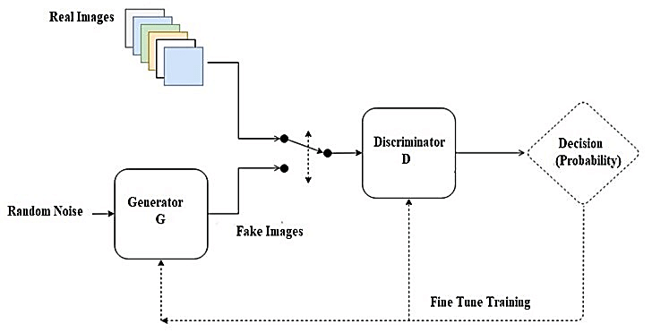

- GANy są oparte na idei *jakość obrazu jest dobra, jeśli nie potrafimy ich odróżnić go od prawdziwych*
- inaczej: *jak rozróżnić czy zbiory przykładów pochodzą z tego samego rozkładu?*
- **generator** uczy się do aż momentu gdy **dyskryminator** nie potrafi już rozróżnić rozkładów danych prawdziwych i wygenerowanych
  - jednak rozpoczynając, modele nie umieją ani generować, ani rozróżniać

### Uczenie GAN

- **dyskryminator** jest binarnym klasyfikatorem rozróżniającym obiekty prawdziwe (real) od wygenerowanych (fake)
  - zwykle MLP zwracający logity i sigmoidę $D(x)$
  - dyskryminator minimalizuje entropię krzyżową $$\underset{D}{\min}\{-y\log{}D(x)-(1-y)\log(1-D(x)\}$$ gdzie $y$ jest równe 1 dla prawdziwych, 0 dla wygenerowanych (fake)
- **generator**
  - losuje $z$ z przestrzeni latent (rozkład jest predefiniowany)
  - wykorzystuje funkcję generatora $x'=G(z)$ (odpowiada dekoderowi)
  - jeśli generator będzie tworzył idealne obrazy, to oczekujemy, że $$D(G(z))\approx1$$
  - generator stara się maksymalizować entropię krzyżową dla $y=0$ $$\underset{G}{\max}\{-(1-y)\log(1-D(G(z)))\}=\underset{G}{\max}\{-\log(1-D(G(z)))\}$$
  - jeśli generator tworzy bardzo dobre obiekty, to $$D(G(z))\approx1$$
    - wtedy powyższy koszt jest bardzo bliski zeru
    - gradienty generatora są bliskie zeru i generator nie będzie się poprawiać
    - lepiej wtedy minimalizować $$\underset{G}{\min}\{-y\log(D(G(z)))\}=\underset{G}{\min}\{-\log(D(G(z)))\}$$
- generator i dyskryminator uczą się **jednocześnie** $$\underset{D}{\min}\underset{G}{\max}\{-\mathbb{E}_{x\sim{}data}\log{}D(x)-\mathbb{E}_{z\sim{}noise}(1-D(G(z)))\}$$
  - to odpowiada **grze minimax**
  - użycie dyskryminatora jest przełączane losowo

### możliwe problemy GAN

- GAN **nie używa** żadnej miary podobieństwa wejściowych i wygenerowanych obiektów
- sprawdza jedynie podobieństwa rozkładów
  - proces uczenia może nie być stabilny
  - oba elementy systemu powinny uczyć się w podobnym tempie
  - wymaga to, aby oba miały podobną pojemność, przy absolutnie różnej architekturze
  - proces wykorzystania przestrzeni latent do jej interpolacji jest utrudniony
- modele GAN są podatne na
  - **mode collapse**
    - zdarza się, ze model generuje jedynie ograniczony zbiór przykładów z przestrzeni danych
      - generator ogranicza się do podprzestrzeni przykładów, gdzie generuje wszystkie w sposób idealny
  - **catastrophic forgetting**
    - gdy model ucząc się, "zapomina" czego nauczył się wcześniej
      - problem tzw. **continual learning**
    - wraz ze zmianą $p_\theta$, generator zmienia przestrzeń rozwiązań, i może zapomnieć stare rozwiązania zwiazane z poprzednimi przykładami
  - **overfitting**
    - dyskryminator dopasowuje się do ograniczonej liczby danych, gdzie osiąga wąskie minimum
    - to skutkuje dużymi płaskimi obszarami gdzie gradient jest bliski zeru
    - model ogranicza się do znalezionych minimów powodując mode collapse